# Funkcje skrótu

*Marcin Kocot*

## Generacja skrótów

Na początku wygenerowano 50 losowych wiadomości. Następnie dla każdej z nich wygenerowano drugą, różniącą się tylko jednym losowym bitem. Dla każdej ze stu uzyskanych wiadomości wygenerowano następujące skróty:

- SHA-256 (SHA-2)
- SHA-512 (SHA-3)
- ASCON

Do wszystkich powyższych operacji użyto języka Python, jako że używany zazwyczaj Kotlin nie posiada biblioteki wspierającej ASCONa.

## Analiza skrótów

Do tej części zadania użyto języka Kotlin. W przypadku testu Hamminga i testu predykcji bitów użyto testu `t` z biblioteki Apache Math3. Mając listę zmierzonych wartości i określoną wartość oczekiwaną, funkcja oblicza p-wartość - można ją następnie porównać do ustalonego poziomu istotności. Biblioteka Math3 sama zajmuje się obliczeniem realnej średniej i odchylenia standardowego.

```kotlin
private fun testMean(
    data: List<Double>,
    expected: Double,
  ): Double {
    val pVal = TTest().tTest(expected, data.toDoubleArray())
    return pVal
  }
```

Dla testu serii statystyka liczona jest *ręcznie*, a p-wartość jest liczona przy użyciu tej samej biblioteki, ale z wykorzystaniem rozkładu normalnego.

```kotlin
NormalDistribution().cumulativeProbability(abs(Z))
```

### Test Hamminga

Każdą parę dwóch skrótów różniących się jednym bitem porównano pod kątem zmienionych bitów. Otrzymano następujące wyniki:

- **SHA-2** - średnia odległość Hamminga to 129,82 bity (wartość oczekiwana 128). Otrzymano p-wartość 0,146.
- **SHA-3** - średnia odległość Hamminga to 255.42 bity (wartość oczekiwana 256). Otrzymano p-wartość 0,703.
- **ASCON** - średnia odległość Hamminga to 128.92 bity (wartość oczekiwana 128). Otrzymano p-wartość 0,521.

W żadnym przypadku nie ma podstaw do odrzucenia hipotezy zerowej, więc wszystkie funkcje spełniają swoją funkcję poprawnie. Co więcej, mówiąc kolokwialnie, najbliżej odrzucenia hipotezy zerowej jesteśmy dla SHA-2, a najdalej dla SHA-3.

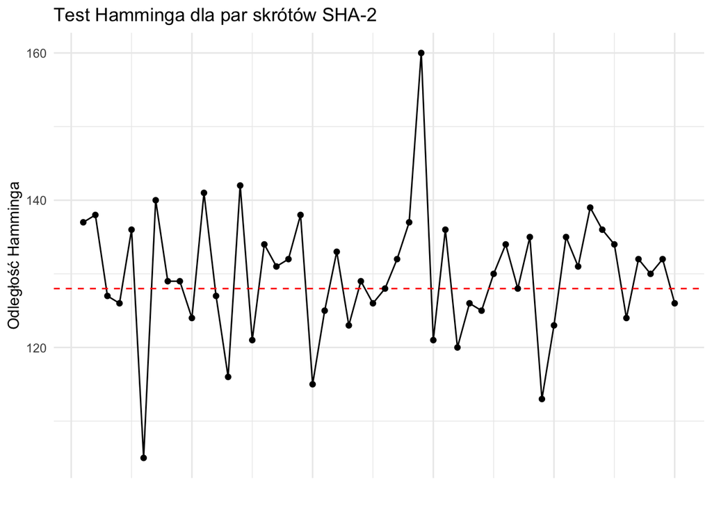

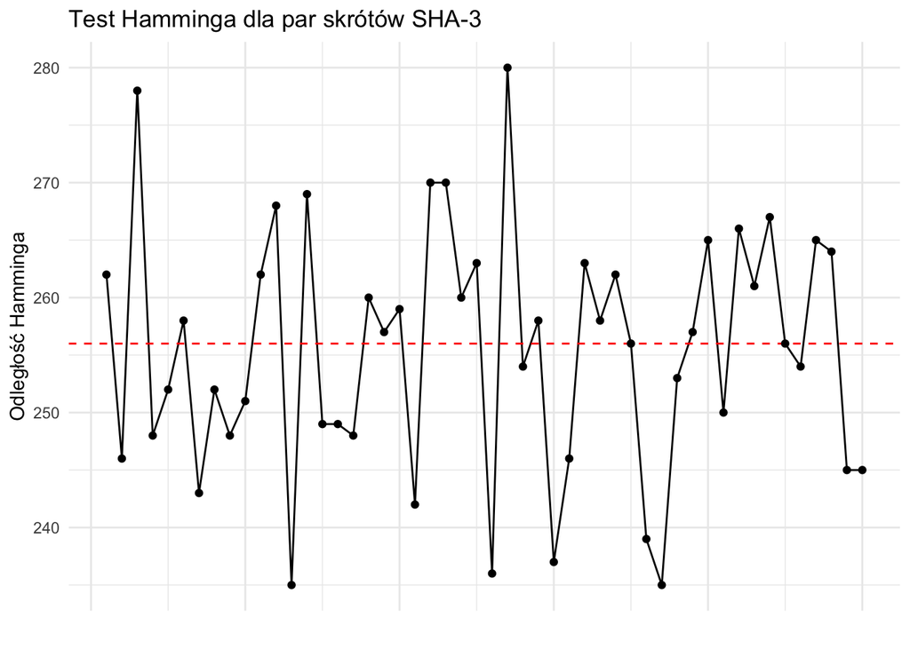

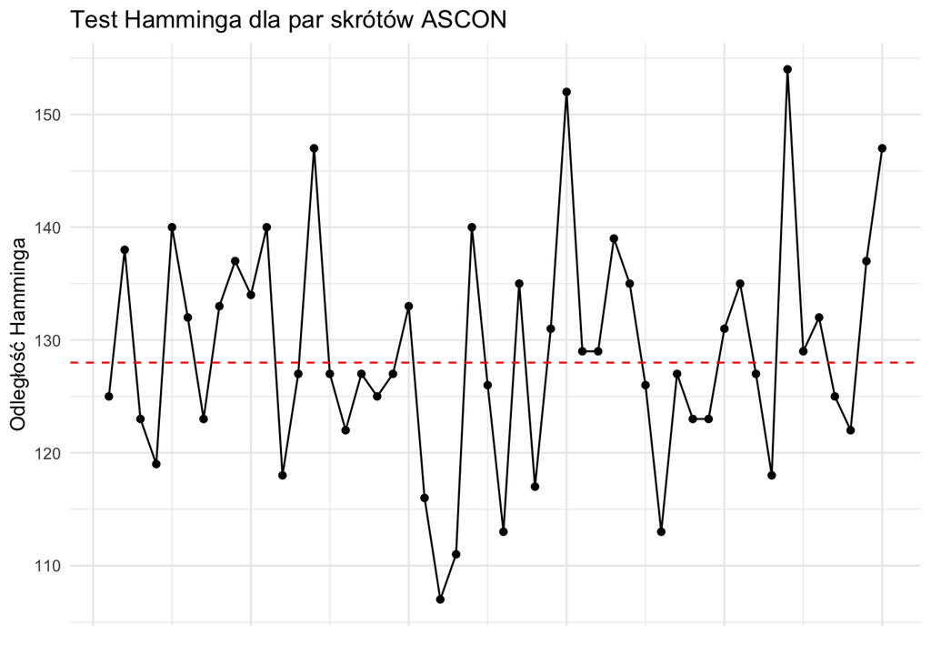

### Test predykcji bitów

Pod uwagę wzięto wszystkie sto skrótów, nie przejmując się tym, że były generowane w parach. Dla każdej pozycji bitów w skrótach policzono szansę bycia jedynką. Uzyskano następujące wyniki:

- **SHA-2** - średnia szansa wyniosła 50,207%. Otrzymano p-wartość 0,528.
- **SHA-3** - średnia szansa wyniosła 49,893%. Otrzymano p-wartość 0,642.
- **ASCON** - średnia szansa wyniosła 49,844%. Otrzymano p-wartość 0,633.

Tak jak w przypadku testu Hamminga, nie ma podstaw do odrzucenia jakiejkolwiek hipotezy zerowej (czyli wartości bitów są nieprzewidywalne).

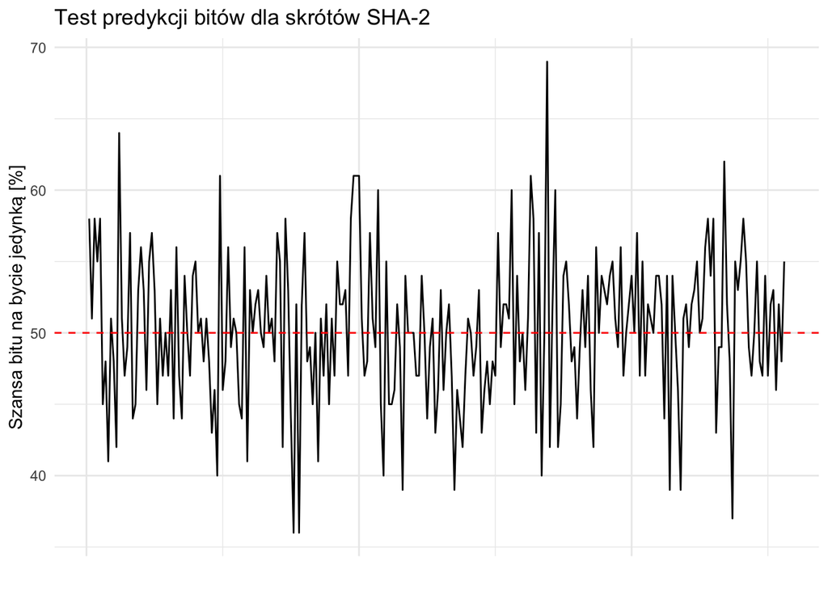

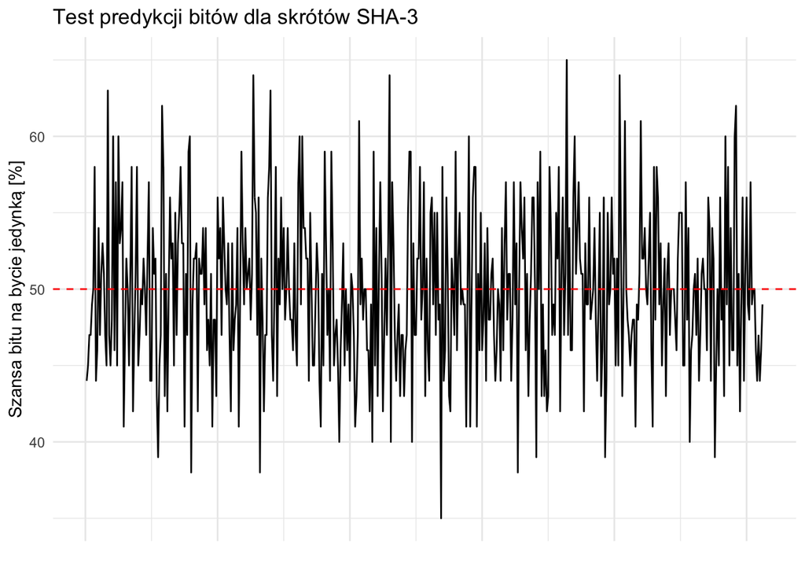

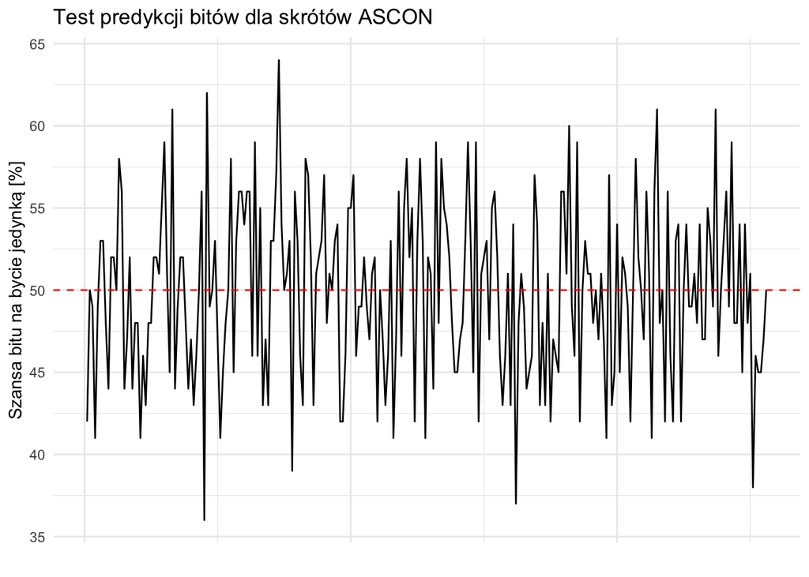

### Test serii

Pod uwagę wzięto wszystkie sto skrótów, nie przejmując się tym, że były generowane w parach. Jako że ten test weryfikuje tylko jeden skrót, policzono sto p-wartości na każdą funkcję skrótu.

- **SHA-2** - p-wartości są w zakresie od 0,016 do 1. Odrzucono dwie ze stu hipotez zerowych.
- **SHA-3** - p-wartości są w zakresie od 0,003 do 1. Odrzucono osiem ze stu hipotez zerowych.
- **ASCON** - p-wartości są w zakresie od 0,001 do 1. Odrzucono pięć ze stu hipotez zerowych.

Test serii przeszło 98% skrótów SHA-2, 92% skrótów SHA-3 i 95% skrótów ASCON.

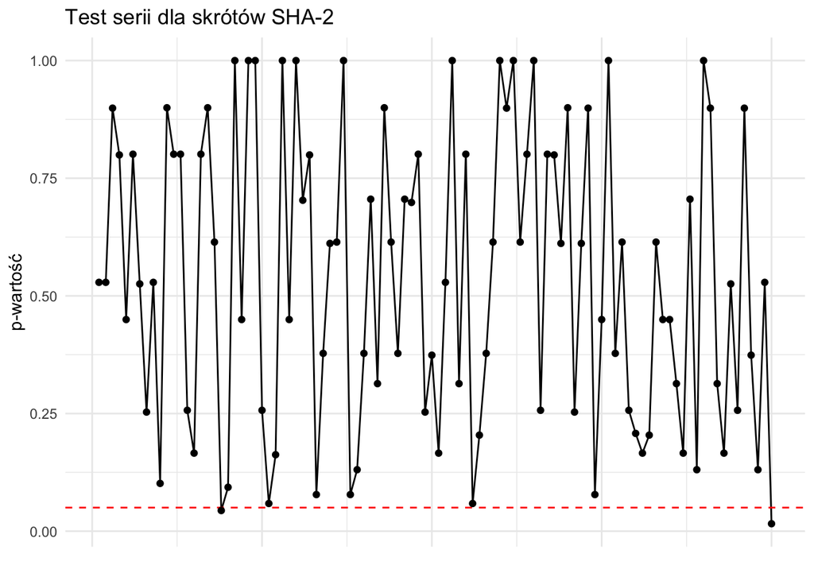

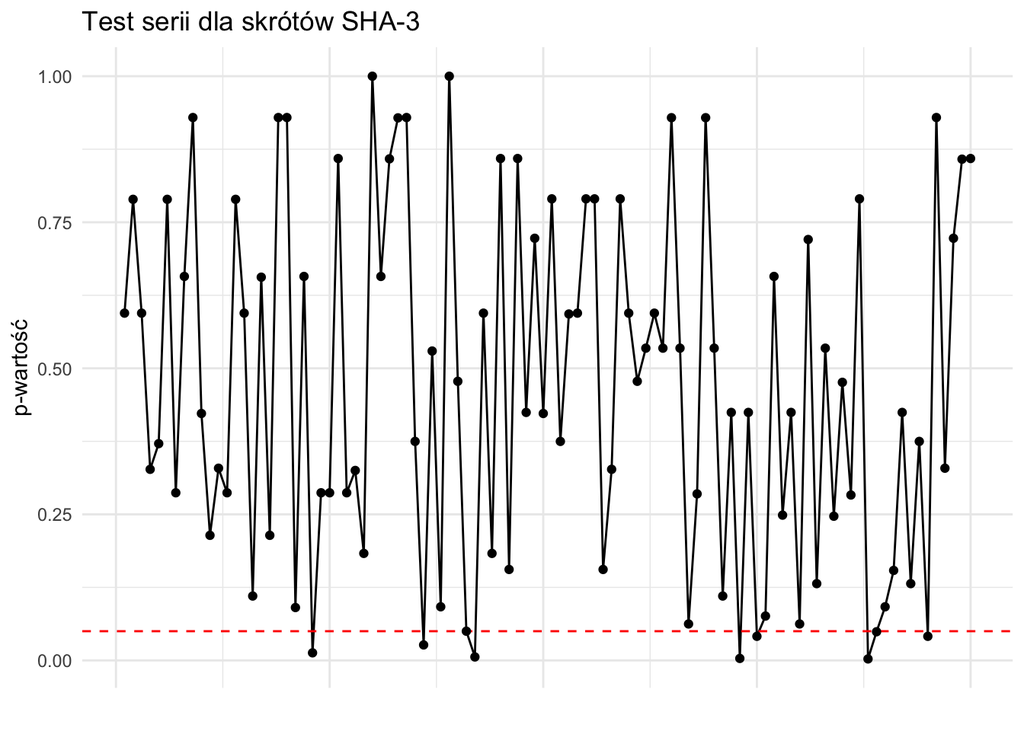

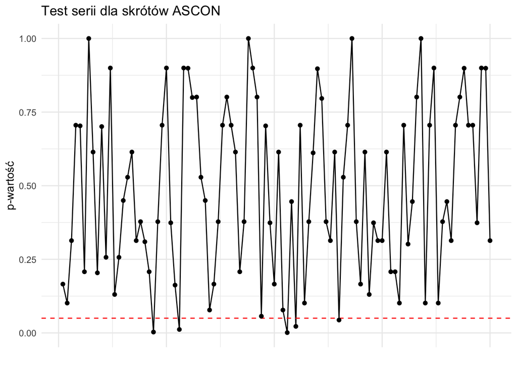